# Explorando Datos de Salarios Municipio Duran

Daniel Vera

16/7/2020

# Análisis exploratorio de datos de salarios del Municipio de Duran-Ecuador

El dataset fue recopilados de los informes de transaparencia del [Municipio de Duran](http://www.duran.gob.ec/municipio/inicio/index.php?option=com_k2&view=itemlist&layout=category&task=category&id=132&Itemid=726)

Tome como referencia un trabajo en Kaggle que explora los datos de [salarios en San Francisco](https://www.kaggle.com/msjgriffiths/explore-sf-salary-data).

```r
library(dplyr)
library(RSQLite)
library(tidyr)
library(ggplot2)
library(readr)
library(stringr)
library(scales)
library(mixtools)
```

## Data

El archivo se encuentra en el directorio `../input`.

```r
list.files("./input")
```

```
## [1] "salarios.csv"
```

Chequeamos el archivo:

```r
data_csv <- read_csv2("./input/salarios.csv", na=c("Not Provided"))
```

```
## Using ',' as decimal and '.' as grouping mark. Use read_delim() for more control.
```

```r
(glimpse(data_csv))
```

```
## Rows: 10,409
## Columns: 15
## $ no                       <dbl> 1, 2, 3, 4, 5, 6, 7, 8, 9, 10, 11, 12, 13,...
## $ nombre                   <chr> "Abad Dumas Hernan Rodrigo", "Acosta Andin...
## $ puesto                   <chr> "Soldador", "Asistente", "Aseador de Calle...
## $ regimenLaboral           <chr> "COD_TRABAJO", "LOSEP", "COD_TRABAJO", "CO...
## $ noPartida                <dbl> 1111510510, 1106510105, 3504710510, 350471...
## $ gradoJerarquico          <chr> "COD_TRABAJO", "SP9", "COD_TRABAJO", "COD_...
## $ remuneracionMensual      <dbl> 548.00, 2034.00, 420.00, 420.00, 622.00, 8...
## $ remuneracionAnual        <dbl> 6576.00, 24408.00, 5040.00, 5040.00, 7464....
## $ decimoTercero            <dbl> 0, 0, 0, 0, 0, 0, 0, 0, 0, 0, 0, 0, 0, 0, ...
## $ DecimoCuarto             <dbl> 0, 0, 0, 0, 0, 0, 0, 0, 0, 0, 0, 0, 0, 0, ...
## $ horasExtras              <dbl> 0.00, 0.00, 0.00, 0.00, 0.00, 0.00, 0.00, ...
## $ encargosSubrogaciones    <dbl> 0, 0, 0, 0, 0, 0, 0, 0, 0, 0, 0, 0, 0, 0, ...
## $ totalIngresosAdicionales <dbl> 0, 0, 0, 0, 0, 0, 0, 0, 0, 0, 0, 0, 0, 0, ...
## $ mes                      <dbl> 1, 1, 1, 1, 1, 1, 1, 1, 1, 1, 1, 1, 1, 1, ...
## $ anio                     <dbl> 2015, 2015, 2015, 2015, 2015, 2015, 2015, ...
```

```
## # A tibble: 10,409 x 15
##       no nombre puesto regimenLaboral noPartida gradoJerarquico remuneracionMen~
##    <dbl> <chr>  <chr>  <chr>              <dbl> <chr>                      <dbl>
##  1     1 Abad ~ Solda~ COD_TRABAJO       1.11e9 COD_TRABAJO                 548
##  2     2 Acost~ Asist~ LOSEP             1.11e9 SP9                        2034
##  3     3 Acost~ Asead~ COD_TRABAJO       3.50e9 COD_TRABAJO                 420
##  4     4 Acost~ Asead~ COD_TRABAJO       3.50e9 COD_TRABAJO                 420
##  5     5 Aguay~ Asist~ LOSEP             1.11e9 SPA2                        622
##  6     6 Aguil~ Asist~ Losep             1.10e9 SP1                         817
##  7     7 Aguil~ Guard~ COD_TRABAJO       1.20e9 COD_TRABAJO                1228.
##  8     8 Aguil~ POLIC~ COD_TRABAJO       1.20e9 COD_TRABAJO                 420
##  9     9 Aguir~ Promo~ LOSEP             2.30e9 SPA2                        622
## 10    10 Aguir~ POLIC~ COD_TRABAJO       1.20e9 COD_TRABAJO                 420
## # ... with 10,399 more rows, and 8 more variables: remuneracionAnual <dbl>,
## #   decimoTercero <dbl>, DecimoCuarto <dbl>, horasExtras <dbl>,
## #   encargosSubrogaciones <dbl>, totalIngresosAdicionales <dbl>, mes <dbl>,
## #   anio <dbl>
```

Limitaremos nuestro analisis al año mas reciente

```r
data <- data_csv %>% filter(anio > 2015)
```

## Análisis exploratorio de datos

Lo primero que me gustaría saber es cómo son las variables.

### Variables No numericas

Para las variables no numéricas (como “puesto”) me gustaría saber:

- ¿Cuántas valores únicos hay?
- ¿Cuál es la frecuencia relativa?

```r
non_numeric_vars <- names(data)[!sapply(data, is.numeric)]
data %>%
    select(one_of(non_numeric_vars)) %>%
    summarise_each(funs(unique_vars = length(unique(.))))
```

```
## # A tibble: 1 x 4
##   nombre_unique_va~ puesto_unique_va~ regimenLaboral_uniqu~ gradoJerarquico_uni~
##               <int>             <int>                 <int>                <int>
## 1               354               127                     2                   26
```

### Puesto de trabajo

Quiero prestar especial atención a `puesto`. ¿Qué información tenemos?

```r
data %>%
    group_by(puesto) %>%
    summarise(Frequency = n()) %>%
    arrange(desc(Frequency)) %>%
    head
```

```
## # A tibble: 6 x 2
##   puesto           Frequency
##   <chr>                <int>
## 1 Asistente               29
## 2 Analista                28
## 3 Jefe                    22
## 4 Director General        16
## 5 Delegado                13
## 6 Tecnico                 12
```

¿Cuántos títulos de trabajo sólo ocurren una vez?

```r
data %>%
    group_by(puesto) %>%
    summarise(Frequency = n()) %>%
    mutate(OccursOnce = Frequency == 1) %>%
    group_by(OccursOnce) %>%
    summarise(Total = n())
```

```
## # A tibble: 2 x 2
##   OccursOnce Total
##   <lgl>      <int>
## 1 FALSE         40
## 2 TRUE          87
```

```r
data %>%
    filter(!duplicated(puesto)) %>%
    head()
```

```
## # A tibble: 6 x 15
##      no nombre puesto regimenLaboral noPartida gradoJerarquico remuneracionMen~
##   <dbl> <chr>  <chr>  <chr>              <dbl> <chr>                      <dbl>
## 1     1 Abad ~ Direc~ Losep             2.20e9 Nomb./NJS4                  3038
## 2     5 Aguay~ Asist~ LOSEP             3.40e9 SPA2                         622
## 3     9 Aguir~ Promo~ LOSEP             2.20e9 SPA2                         622
## 4    17 Aizpr~ Asist~ Losep             1.11e9 SPA3                         675
## 5    21 Albuj~ Terap~ LOSEP             2.20e9 SP5                         1212
## 6    22 Albuj~ Super~ LOSEP             3.40e9 SP4                         1086
## # ... with 8 more variables: remuneracionAnual <dbl>, decimoTercero <dbl>,
## #   DecimoCuarto <dbl>, horasExtras <dbl>, encargosSubrogaciones <dbl>,
## #   totalIngresosAdicionales <dbl>, mes <dbl>, anio <dbl>
```

Algunos parecen cargos altos. ¿Cómo se compara la paga con la de las personas que comparten un título?

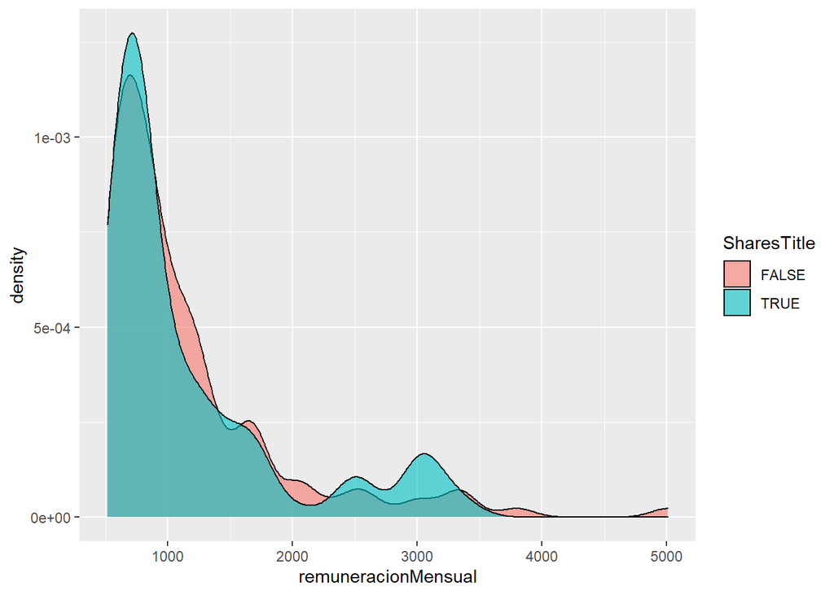

```r
data %>%
    mutate(SharesTitle = duplicated(puesto)) %>%
    ggplot(aes(x = remuneracionMensual)) +
    geom_density(aes(fill = SharesTitle), alpha = 0.6)
```

### Variables numericas

Veamos un resumen de las variables numericas.

```r
data %>%
    select(-one_of(non_numeric_vars)) %>%
    summary
```

```
##        no          noPartida         remuneracionMensual remuneracionAnual
##  Min.   :  1.0   Min.   :1.102e+09   Min.   : 515        Min.   : 6180
##  1st Qu.:182.2   1st Qu.:1.112e+09   1st Qu.: 675        1st Qu.: 8100
##  Median :420.0   Median :2.203e+09   Median : 817        Median : 9804
##  Mean   :421.3   Mean   :2.379e+09   Mean   :1160        Mean   :13922
##  3rd Qu.:644.8   3rd Qu.:3.404e+09   3rd Qu.:1412        3rd Qu.:16944
##  Max.   :862.0   Max.   :3.506e+09   Max.   :5009        Max.   :60108
##
##  decimoTercero     DecimoCuarto     horasExtras     encargosSubrogaciones
##  Min.   :  0.00   Min.   : 0.000   Min.   :  0.00   Min.   : NA
##  1st Qu.:  0.00   1st Qu.: 0.000   1st Qu.:  0.00   1st Qu.: NA
##  Median :  0.00   Median : 0.000   Median :  0.00   Median : NA
##  Mean   : 10.17   Mean   : 2.384   Mean   : 16.45   Mean   :NaN
##  3rd Qu.:  0.00   3rd Qu.: 0.000   3rd Qu.:  0.00   3rd Qu.: NA
##  Max.   :278.25   Max.   :30.500   Max.   :675.75   Max.   : NA
##                                                     NA's   :354
##  totalIngresosAdicionales      mes         anio
##  Min.   : NA              Min.   :1   Min.   :2016
##  1st Qu.: NA              1st Qu.:1   1st Qu.:2016
##  Median : NA              Median :1   Median :2016
##  Mean   :NaN              Mean   :1   Mean   :2016
##  3rd Qu.: NA              3rd Qu.:1   3rd Qu.:2016
##  Max.   : NA              Max.   :1   Max.   :2016
##  NA's   :354
```

OK. Me llama la atencion las cifras de `horasExtras`

Quienes tienen horas extras?

```r
data %>%
    filter(horasExtras > 0)
```

```
## # A tibble: 13 x 15
##       no nombre puesto regimenLaboral noPartida gradoJerarquico remuneracionMen~
##    <dbl> <chr>  <chr>  <chr>              <dbl> <chr>                      <dbl>
##  1    37 Alvar~ POLIC~ LOSEP             3.51e9 SPS2                         553
##  2   134 Caden~ POLIC~ LOSEP             3.51e9 SPA2                         622
##  3   257 Fienc~ POLIC~ LOSEP             3.51e9 SPS1                         527
##  4   282 Giral~ Super~ LOSEP             3.50e9 SP3                          986
##  5   298 Gonza~ Super~ Losep             3.51e9 SPA3                         675
##  6   492 Moren~ Super~ LOSEP             3.51e9 SP2                          901
##  7   541 Orell~ CHOFER LOSEP             1.10e9 SPA4                         733
##  8   560 Pared~ POLIC~ LOSEP             3.51e9 SPA2                         622
##  9   638 Ramir~ POLIC~ LOSEP             3.51e9 SPA1                         585
## 10   724 Sandi~ POLIC~ LOSEP             3.51e9 SPA2                         622
## 11   758 Toapa~ Super~ Losep             3.51e9 SP2                          901
## 12   824 Vera ~ POLIC~ LOSEP             3.51e9 SPA1                         585
## 13   830 Villa~ POLIC~ LOSEP             3.51e9 SPA1                         585
## # ... with 8 more variables: remuneracionAnual <dbl>, decimoTercero <dbl>,
## #   DecimoCuarto <dbl>, horasExtras <dbl>, encargosSubrogaciones <dbl>,
## #   totalIngresosAdicionales <dbl>, mes <dbl>, anio <dbl>
```

13 personas tienen pagos por sobretiempo. La mayoria son policias municipales.

### Sueldos y Regimen Laboral

Veamos una rapida mirada.

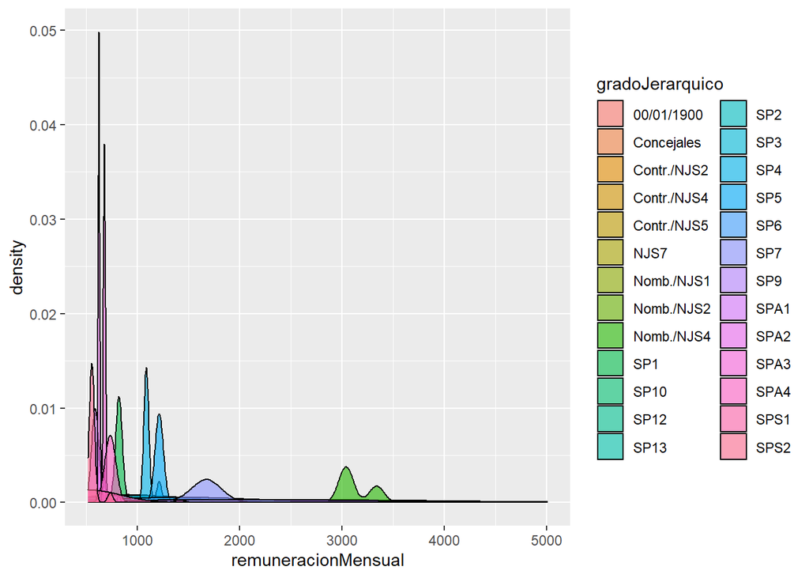

```r
data %>%
    ggplot(aes(x = remuneracionMensual)) +
    geom_density(aes(fill = gradoJerarquico), alpha = 0.6)
```

### Grados Jerarquicos

Tenemos la columna `gradoJerarquico` que al parecer indica el nivel de los empleados. Hechemos un vistazo.

```r
# Subset down
data %>%
    filter(!is.na(gradoJerarquico)) ->
    jobs_with_levels

# Peek
(head(jobs_with_levels))
```

```
## # A tibble: 6 x 15
##      no nombre puesto regimenLaboral noPartida gradoJerarquico remuneracionMen~
##   <dbl> <chr>  <chr>  <chr>              <dbl> <chr>                      <dbl>
## 1     1 Abad ~ Direc~ Losep             2.20e9 Nomb./NJS4                  3038
## 2     5 Aguay~ Asist~ LOSEP             3.40e9 SPA2                         622
## 3     6 Aguil~ Asist~ Losep             1.10e9 SP1                          817
## 4     9 Aguir~ Promo~ LOSEP             2.20e9 SPA2                         622
## 5    11 Aguir~ Direc~ LOSEP             1.11e9 Nomb./NJS4                  3038
## 6    17 Aizpr~ Asist~ Losep             1.11e9 SPA3                         675
## # ... with 8 more variables: remuneracionAnual <dbl>, decimoTercero <dbl>,
## #   DecimoCuarto <dbl>, horasExtras <dbl>, encargosSubrogaciones <dbl>,
## #   totalIngresosAdicionales <dbl>, mes <dbl>, anio <dbl>
```

```r
jobs_with_levels %>%
    group_by(gradoJerarquico) %>%
    summarise(People = n(), Titles = n_distinct(puesto))
```

```
## # A tibble: 26 x 3
##    gradoJerarquico People Titles
##    <chr>            <int>  <int>
##  1 00/01/1900           9      8
##  2 Concejales          11      1
##  3 Contr./NJS2          1      1
##  4 Contr./NJS4          1      1
##  5 Contr./NJS5          1      1
##  6 NJS7                 1      1
##  7 Nomb./NJS1           1      1
##  8 Nomb./NJS2           1      1
##  9 Nomb./NJS4          19      4
## 10 SP1                 48     21
## # ... with 16 more rows
```

Al parecer, tenemos la mayoria se encuentra en los niveles SP1 y SPA3.

Bueno, ¿cómo se comparan los niveles?

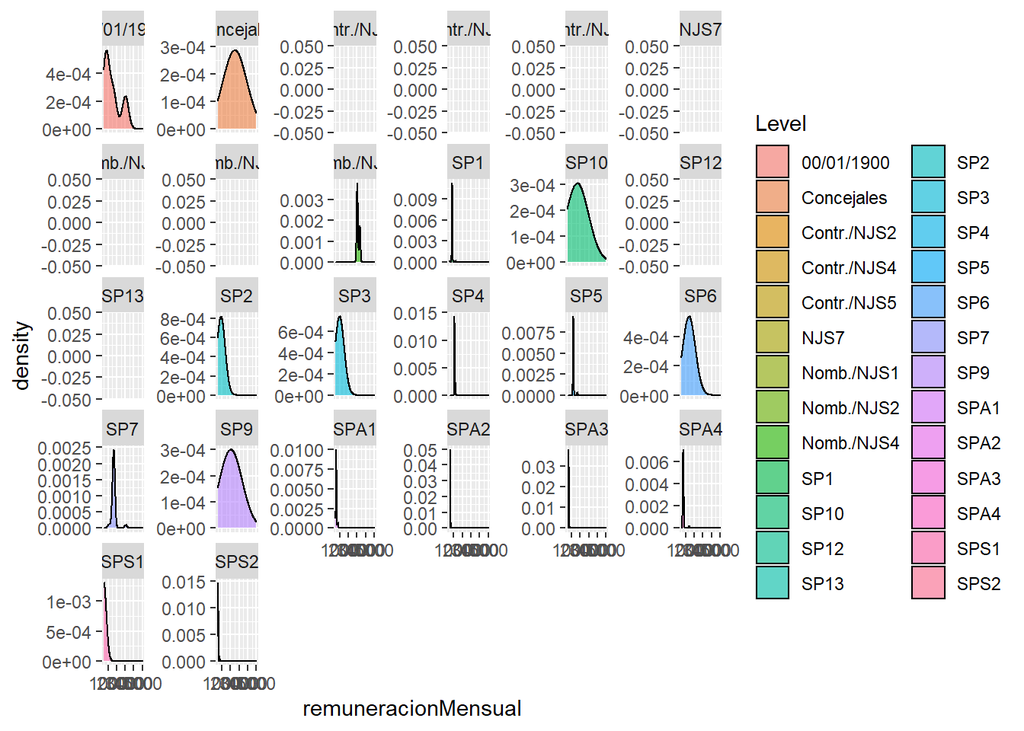

```r
data %>%
    mutate(Level = ifelse(is.na(gradoJerarquico), "No Level", gradoJerarquico)) %>%
    ggplot(aes(x = remuneracionMensual)) +
    geom_density(aes(fill = Level), alpha = 0.6) +
    facet_wrap(~Level, scales="free_y")
```

## Consluciones

Soy muy nuevo en el mundo de la ciencia de datos y analisis estadisticos. La idea con este ejercicio es tratar de mejorar el analisis con cada nuevo conocimiento adquirido y aplicarlo en este conjunto de datos que he recopilado y que estare actualizando con los datos que vayan surgiendo.